# Mucosal microbiota alterations in primary sclerosis cholangitis persist after liver transplantation and are associated with clinical features independently of geography

### 3.1.1 Sequencing depth

```r
data_filt <- seq_depth_filtering(colon_asv_tab,
                                 colon_taxa_tab,
                                 colon_metadata,
                                 seq_depth_threshold = 10000)
```

```
Removing 75 ASV(s)
```

```r
filt_colon_asv_tab <- data_filt[[1]]; alpha_colon_asv_tab <- filt_colon_asv_tab
filt_colon_taxa_tab <- data_filt[[2]]; alpha_colon_taxa_tab <- filt_colon_taxa_tab
filt_colon_metadata <- data_filt[[3]]; alpha_colon_metadata <- filt_colon_metadata

seq_step <- dim(filt_colon_asv_tab)[1]
```

Library size

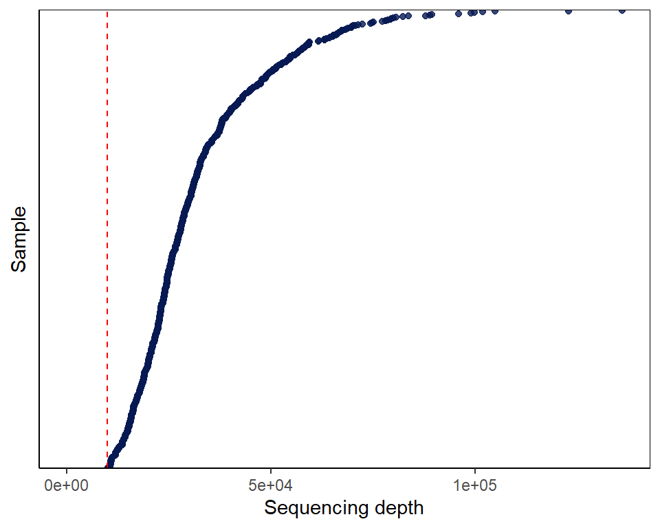

```r
read_counts(filt_colon_asv_tab,line = c(10000))
```

### 3.1.2 NearZeroVar

```r
data_filt <- nearzerovar_filtering(filt_colon_asv_tab,
                                   filt_colon_taxa_tab,
                                   filt_colon_metadata)

filt_colon_asv_tab <- data_filt[[1]]
filt_colon_taxa_tab <- data_filt[[2]]
nearzero_step <- dim(filt_colon_asv_tab)[1]
```

Library size

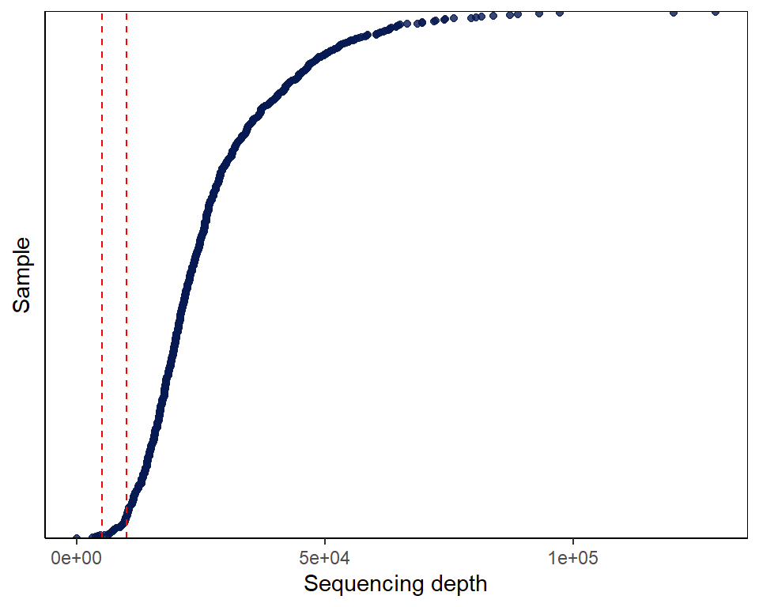

```r
read_counts(filt_colon_asv_tab,line = c(5000,10000))
```

Check zero depth

```r
data_filt <- check_zero_depth(filt_colon_asv_tab,
                              filt_colon_taxa_tab,
                              filt_colon_metadata)

filt_colon_asv_tab <- data_filt[[1]];
filt_colon_taxa_tab <- data_filt[[2]];
filt_colon_metadata <- data_filt[[3]];
```

Library size

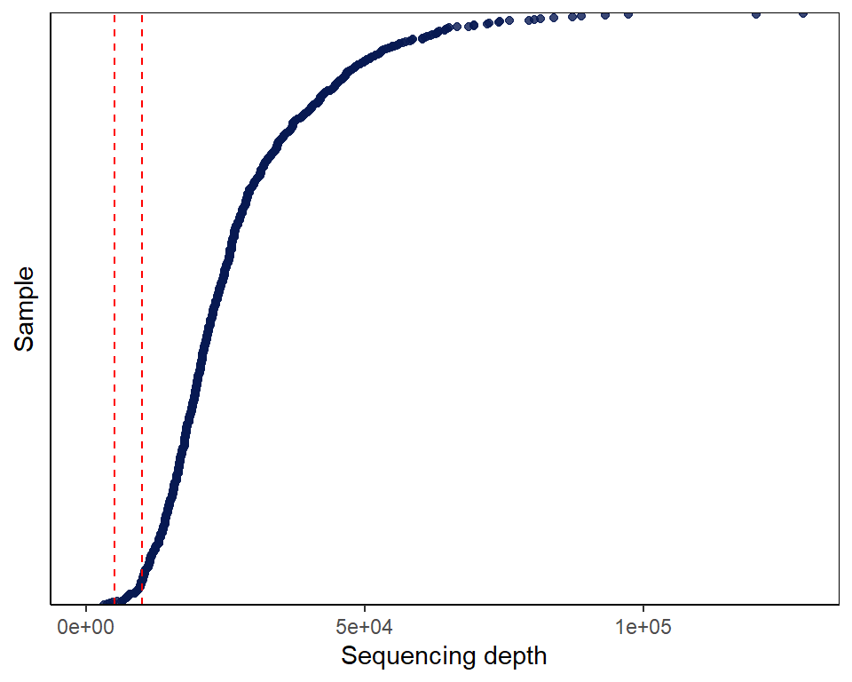

```r
read_counts(filt_colon_asv_tab,line = c(5000,10000))
```

### 3.1.3 Final Counts

```r
final_counts_filtering(colon_asv_tab,
                       filt_colon_asv_tab,
                       filt_colon_metadata,
                       seq_step, 0, nearzero_step)
```

```
                                               V1
Raw data: ASVs                               6936
Raw data: Samples                             789
Sequencing depth filt: ASVs                  6861
Prevalence filt: ASVs                           0
NearZeroVar filt: ASVs                        381
Filt data: ASVs                               381
Filt data: Samples                            760
Filt data: Patients                           354
Filt data: Patients.1                           0
Filtered samples                               29
Matrices                    Cecum;Rectum;CD;CA;SI
healthy                                       161
non-rPSC                                        0
rPSC                                            0
pre_ltx                                       250
post_ltx                                      349
ETOH                                            0
```

## 3.2 Alpha diversity

Calculating Richness, Shannon, Simpson, Pielou indexes on raw (unfiltered) rarefied data. Samples with sequencing depth < 10000 were excluded. Testing by linear mixed-effect model.

```r
path = "../results/Q1/alpha_diversity"
```

**Calculation**

```r
# Construct MPSE object
alpha_colon_metadata$Sample <- alpha_colon_metadata$SampleID
colon_mpse <- as.MPSE(construct_phyloseq(alpha_colon_asv_tab,
                                         alpha_colon_taxa_tab,
                                         alpha_colon_metadata))

colon_mpse %<>% mp_rrarefy(raresize = 10000,seed = 123)

# Calculate alpha diversity - rarefied counts
colon_mpse %<>% mp_cal_alpha(.abundance=RareAbundance, force=TRUE)
```

```r
alpha_data <- data.frame(SampleID=colon_mpse$Sample.x,
                         Observe=colon_mpse$Observe,
                         Shannon=colon_mpse$Shannon,
                         Simpson=colon_mpse$Simpson,
                         Pielou=colon_mpse$Pielou,
                         Group=colon_mpse$Group,
                         Country=colon_mpse$Country,
                         Patient=colon_mpse$Patient)

write.csv(alpha_data,file.path(path,paste0("alpha_indices_",segment,".csv")),
          row.names = FALSE)
```

### 3.2.1 Plots

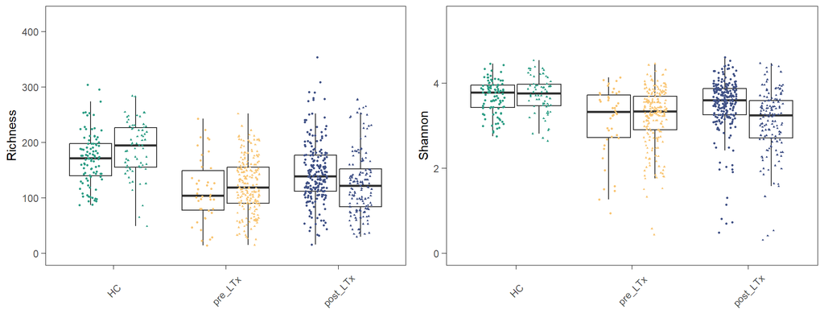

```r
p_boxplot_alpha <- alpha_diversity_countries(alpha_data)
# save the results
alpha_div_plots[[paste(segment,"Country")]] <- p_boxplot_alpha

# see the results
p_boxplot_alpha
```

### 3.2.2 Linear Model

```r
path = "../results/Q1/alpha_diversity"
alpha_data <- read.csv(file.path(path,paste0("alpha_indices_",segment,".csv")))
```

**Richness**

```r
results_model <- pairwise.lmer(
  formula = "Observe ~ Group * Country + (1|Patient)",
  factors=alpha_data$Group,
  data=alpha_data)

# check interaction
if (!is.data.frame(results_model)){
  results_model_observe <- results_model[[1]]
  results_model_observe_detailed <- results_model[[2]]
} else {
  results_model_observe <- results_model
  results_model_observe_detailed <- NA
}

# save the results
pc_observed[[segment]] <- results_model_observe
```

```r
# see the results
knitr::kable(results_model_observe,digits = 3,
caption = "Raw results of linear model of richness estimation.")
```

Raw results of linear model of richness estimation.

|  | Estimate | Std..Error | df | t.value | Pr…t.. | p.adj | sig |
| --- | --- | --- | --- | --- | --- | --- | --- |
| healthy vs Grouppre_ltx | -56.230 | 11.738 | 195.570 | -4.791 | 0.000 | 0.000 | *** |
| healthy vs pre_ltx - CZ vs NO | 14.193 | 10.341 | 194.538 | 1.372 | 0.171 | 0.256 |  |
| healthy vs Grouppre_ltx:CountryNO | -7.489 | 15.169 | 194.358 | -0.494 | 0.622 | 0.622 |  |
| pre_ltx vs Grouppost_ltx | 28.886 | 11.811 | 267.502 | 2.446 | 0.015 | 0.045 | * |
| pre_ltx vs post_ltx - CZ vs NO | 6.742 | 12.174 | 265.784 | 0.554 | 0.580 | 0.622 |  |
| pre_ltx vs Grouppost_ltx:CountryNO | -24.047 | 15.112 | 262.828 | -1.591 | 0.113 | 0.203 |  |
| healthy vs Grouppost_ltx | -27.299 | 8.699 | 250.458 | -3.138 | 0.002 | 0.009 | ** |
| healthy vs post_ltx - CZ vs NO | 14.360 | 11.153 | 251.729 | 1.288 | 0.199 | 0.256 |  |
| healthy vs Grouppost_ltx:CountryNO | -31.681 | 14.195 | 247.531 | -2.232 | 0.027 | 0.060 |  |

```r
knitr::kable(results_model_observe_detailed,digits = 3,
caption = "Raw results of independent country analysis")
```

Raw results of independent country analysis

|  | Estimate | Std. Error | df | t value | Pr(>\|t\|) | p.adjusted |
| --- | --- | --- | --- | --- | --- | --- |
| healthy_CZ | 171.780 | 7.001 | 162.548 | 24.535 | 0.000 | NA |
| Grouppost_ltx | -27.276 | 8.558 | 161.345 | -3.187 | 0.002 | 0.003 |

|  | Estimate | Std. Error | df | t value | Pr(>\|t\|) | p.adjusted |
| --- | --- | --- | --- | --- | --- | --- |
| healthy_NO | 186.110 | 8.829 | 88.980 | 21.080 | 0 | NA |
| Grouppost_ltx | -58.943 | 11.539 | 87.242 | -5.108 | 0 | 0 |

|  | Estimate | Std. Error | df | t value | Pr(>\|t\|) | p.adjusted |
| --- | --- | --- | --- | --- | --- | --- |
| healthy_CZ | 171.793 | 6.342 | 89.560 | 27.090 | 0.000 | NA |
| CountryNO | 14.358 | 9.941 | 89.408 | 1.444 | 0.152 | 0.152 |

|  | Estimate | Std. Error | df | t value | Pr(>\|t\|) | p.adjusted |
| --- | --- | --- | --- | --- | --- | --- |
| post_ltx_CZ | 144.490 | 5.283 | 158.786 | 27.352 | 0.000 | NA |
| CountryNO | -17.319 | 9.272 | 154.970 | -1.868 | 0.064 | 0.085 |

**Shannon**

```r
results_model <- pairwise.lmer(
  formula = "Shannon ~ Group * Country + (1|Patient)",
  factors=alpha_data$Group,
  data=alpha_data)

# check interaction
if (!is.data.frame(results_model)){
  results_model_shannon <- results_model[[1]]
  results_model_shannon_detailed <- results_model[[2]]
} else {
  results_model_shannon <- results_model
  results_model_shannon_detailed <- NA
}

# save the results
pc_shannon[[segment]] <- as.data.frame(results_model_shannon)
```

```r
# see the results
knitr::kable(results_model_shannon,digits = 3,
caption = "Raw results of linear model of Shannon estimation.")
```

Raw results of linear model of Shannon estimation.

|  | Estimate | Std..Error | df | t.value | Pr…t.. | p.adj | sig |
| --- | --- | --- | --- | --- | --- | --- | --- |
| healthy vs Grouppre_ltx | -0.585 | 0.143 | 197.588 | -4.084 | 0.000 | 0.001 | *** |
| healthy vs pre_ltx - CZ vs NO | 0.015 | 0.126 | 196.213 | 0.116 | 0.907 | 0.909 |  |
| healthy vs Grouppre_ltx:CountryNO | 0.081 | 0.185 | 195.965 | 0.437 | 0.663 | 0.852 |  |
| pre_ltx vs Grouppost_ltx | 0.364 | 0.158 | 265.003 | 2.307 | 0.022 | 0.056 |  |
| pre_ltx vs post_ltx - CZ vs NO | 0.095 | 0.163 | 263.448 | 0.585 | 0.559 | 0.839 |  |
| pre_ltx vs Grouppost_ltx:CountryNO | -0.455 | 0.202 | 260.765 | -2.253 | 0.025 | 0.056 |  |
| healthy vs Grouppost_ltx | -0.220 | 0.102 | 247.586 | -2.153 | 0.032 | 0.058 |  |
| healthy vs post_ltx - CZ vs NO | 0.015 | 0.131 | 248.759 | 0.114 | 0.909 | 0.909 |  |
| healthy vs Grouppost_ltx:CountryNO | -0.376 | 0.167 | 244.904 | -2.255 | 0.025 | 0.056 |  |

```r
knitr::kable(results_model_shannon_detailed,digits = 3,
caption = "Raw results of independent country analysis")
```

Raw results of independent country analysis

|  | Estimate | Std. Error | df | t value | Pr(>\|t\|) | p.adjusted |
| --- | --- | --- | --- | --- | --- | --- |
| pre_ltx_CZ | 3.102 | 0.144 | 131.105 | 21.535 | 0.000 | NA |
| Grouppost_ltx | 0.363 | 0.160 | 130.742 | 2.275 | 0.025 | 0.049 |

|  | Estimate | Std. Error | df | t value | Pr(>\|t\|) | p.adjusted |
| --- | --- | --- | --- | --- | --- | --- |
| pre_ltx_NO | 3.197 | 0.078 | 129.531 | 41.004 | 0.000 | NA |
| Grouppost_ltx | -0.091 | 0.125 | 129.050 | -0.732 | 0.466 | 0.563 |

|  | Estimate | Std. Error | df | t value | Pr(>\|t\|) | p.adjusted |
| --- | --- | --- | --- | --- | --- | --- |
| pre_ltx_CZ | 3.101 | 0.143 | 105.863 | 21.629 | 0.000 | NA |
| CountryNO | 0.095 | 0.164 | 104.934 | 0.580 | 0.563 | 0.563 |

|  | Estimate | Std. Error | df | t value | Pr(>\|t\|) | p.adjusted |
| --- | --- | --- | --- | --- | --- | --- |
| post_ltx_CZ | 3.466 | 0.068 | 156.394 | 51.151 | 0.000 | NA |
| CountryNO | -0.360 | 0.119 | 153.436 | -3.025 | 0.003 | 0.012 |

|  | Estimate | Std. Error | df | t value | Pr(>\|t\|) | p.adjusted |
| --- | --- | --- | --- | --- | --- | --- |
| healthy_CZ | 3.686 | 0.082 | 159.084 | 44.805 | 0.00 | NA |
| Grouppost_ltx | -0.220 | 0.101 | 158.215 | -2.190 | 0.03 | 0.04 |

|  | Estimate | Std. Error | df | t value | Pr(>\|t\|) | p.adjusted |
| --- | --- | --- | --- | --- | --- | --- |
| healthy_NO | 3.701 | 0.104 | 90.164 | 35.654 | 0 | NA |
| Grouppost_ltx | -0.596 | 0.136 | 88.069 | -4.396 | 0 | 0 |

|  | Estimate | Std. Error | df | t value | Pr(>\|t\|) | p.adjusted |
| --- | --- | --- | --- | --- | --- | --- |
| healthy_CZ | 3.685 | 0.054 | 89.090 | 68.738 | 0.000 | NA |
| CountryNO | 0.017 | 0.084 | 88.849 | 0.205 | 0.838 | 0.838 |

|  | Estimate | Std. Error | df | t value | Pr(>\|t\|) | p.adjusted |
| --- | --- | --- | --- | --- | --- | --- |
| post_ltx_CZ | 3.466 | 0.068 | 156.394 | 51.151 | 0.000 | NA |
| CountryNO | -0.360 | 0.119 | 153.436 | -3.025 | 0.003 | 0.006 |

**Simpson**

```r
results_model <- pairwise.lmer(
  formula = "Simpson ~ Group * Country + (1|Patient)",
  factors=alpha_data$Group,
  data=alpha_data)

# check interaction
if (!is.data.frame(results_model)){
  results_model_simpson <- results_model[[1]]
  results_model_simpson_detailed <- results_model[[2]]
} else {
  results_model_simpson <- results_model
  results_model_simpson_detailed <- NA
}

# save the results
pc_simpson[[segment]] <- as.data.frame(results_model_simpson)
```

```r
# see the results
knitr::kable(results_model_simpson,digits = 3,
caption = "Raw results of linear model of Simpson estimation.")
```

Raw results of linear model of Simpson estimation.

|  | Estimate | Std..Error | df | t.value | Pr…t.. | p.adj | sig |
| --- | --- | --- | --- | --- | --- | --- | --- |
| healthy vs Grouppre_ltx | -0.059 | 0.019 | 199.853 | -3.066 | 0.002 | 0.022 | * |
| healthy vs pre_ltx - CZ vs NO | -0.007 | 0.017 | 198.127 | -0.430 | 0.667 | 0.738 |  |
| healthy vs Grouppre_ltx:CountryNO | 0.020 | 0.025 | 197.803 | 0.813 | 0.417 | 0.626 |  |
| pre_ltx vs Grouppost_ltx | 0.031 | 0.026 | 263.530 | 1.213 | 0.226 | 0.455 |  |
| pre_ltx vs post_ltx - CZ vs NO | 0.013 | 0.027 | 261.964 | 0.476 | 0.635 | 0.738 |  |
| pre_ltx vs Grouppost_ltx:CountryNO | -0.052 | 0.033 | 259.262 | -1.556 | 0.121 | 0.363 |  |
| healthy vs Grouppost_ltx | -0.027 | 0.017 | 246.082 | -1.594 | 0.112 | 0.363 |  |
| healthy vs post_ltx - CZ vs NO | -0.007 | 0.022 | 247.135 | -0.335 | 0.738 | 0.738 |  |
| healthy vs Grouppost_ltx:CountryNO | -0.032 | 0.028 | 243.697 | -1.147 | 0.253 | 0.455 |  |

```r
knitr::kable(results_model_simpson_detailed,digits = 3,
caption = "Raw results of independent country analysis")
```

Table: Raw results of independent country analysis

**Pielou**

```r
results_model <- pairwise.lmer(
  formula = "Pielou ~ Group * Country + (1|Patient)",
  factors=alpha_data$Group,
  data=alpha_data)

# check interaction
if (!is.data.frame(results_model)){
  results_model_pielou <- results_model[[1]]
  results_model_pielou_detailed <- results_model[[2]]
} else {
  results_model_pielou <- results_model
  results_model_pielou_detailed <- NA
}

# save the results
pc_pielou[[segment]] <- as.data.frame(results_model_pielou)
```

```r
# see the results
knitr::kable(results_model_pielou,digits = 3,
caption = "Raw results of linear model of Pielou estimation.")
```

Raw results of linear model of Pielou estimation.

|  | Estimate | Std..Error | df | t.value | Pr…t.. | p.adj | sig |
| --- | --- | --- | --- | --- | --- | --- | --- |
| healthy vs Grouppre_ltx | -0.057 | 0.020 | 201.130 | -2.828 | 0.005 | 0.046 | * |
| healthy vs pre_ltx - CZ vs NO | -0.008 | 0.018 | 199.017 | -0.446 | 0.656 | 0.781 |  |
| healthy vs Grouppre_ltx:CountryNO | 0.015 | 0.026 | 198.602 | 0.565 | 0.573 | 0.781 |  |
| pre_ltx vs Grouppost_ltx | 0.039 | 0.024 | 265.797 | 1.631 | 0.104 | 0.234 |  |
| pre_ltx vs post_ltx - CZ vs NO | 0.007 | 0.025 | 263.735 | 0.274 | 0.785 | 0.785 |  |
| pre_ltx vs Grouppost_ltx:CountryNO | -0.062 | 0.031 | 260.213 | -2.015 | 0.045 | 0.202 |  |
| healthy vs Grouppost_ltx | -0.018 | 0.016 | 247.076 | -1.130 | 0.260 | 0.467 |  |
| healthy vs post_ltx - CZ vs NO | -0.008 | 0.020 | 248.451 | -0.394 | 0.694 | 0.781 |  |
| healthy vs Grouppost_ltx:CountryNO | -0.047 | 0.026 | 243.881 | -1.828 | 0.069 | 0.206 |  |

```r
knitr::kable(results_model_pielou_detailed,digits = 3,
caption = "Raw results of independent country analysis")
```

Raw results of independent country analysis

|  | Estimate | Std. Error | df | t value | Pr(>\|t\|) | p.adjusted |
| --- | --- | --- | --- | --- | --- | --- |
| pre_ltx_CZ | 0.664 | 0.022 | 130.842 | 29.916 | 0.000 | NA |
| Grouppost_ltx | 0.039 | 0.025 | 130.452 | 1.582 | 0.116 | 0.232 |

|  | Estimate | Std. Error | df | t value | Pr(>\|t\|) | p.adjusted |
| --- | --- | --- | --- | --- | --- | --- |
| pre_ltx_NO | 0.670 | 0.012 | 129.502 | 57.528 | 0.000 | NA |
| Grouppost_ltx | -0.023 | 0.019 | 128.819 | -1.219 | 0.225 | 0.3 |

|  | Estimate | Std. Error | df | t value | Pr(>\|t\|) | p.adjusted |
| --- | --- | --- | --- | --- | --- | --- |
| pre_ltx_CZ | 0.664 | 0.020 | 107.760 | 32.578 | 0.000 | NA |
| CountryNO | 0.007 | 0.023 | 106.251 | 0.291 | 0.772 | 0.772 |

|  | Estimate | Std. Error | df | t value | Pr(>\|t\|) | p.adjusted |
| --- | --- | --- | --- | --- | --- | --- |
| post_ltx_CZ | 0.703 | 0.011 | 155.706 | 65.557 | 0.000 | NA |
| CountryNO | -0.055 | 0.019 | 152.292 | -2.919 | 0.004 | 0.016 |

|  | Estimate | Std. Error | df | t value | Pr(>\|t\|) | p.adjusted |
| --- | --- | --- | --- | --- | --- | --- |
| healthy_CZ | 0.721 | 0.013 | 158.287 | 55.872 | 0.000 | NA |
| Grouppost_ltx | -0.018 | 0.016 | 157.427 | -1.146 | 0.254 | 0.338 |

|  | Estimate | Std. Error | df | t value | Pr(>\|t\|) | p.adjusted |
| --- | --- | --- | --- | --- | --- | --- |
| healthy_NO | 0.713 | 0.016 | 92.108 | 44.931 | 0.000 | NA |
| Grouppost_ltx | -0.065 | 0.021 | 89.257 | -3.151 | 0.002 | 0.008 |

|  | Estimate | Std. Error | df | t value | Pr(>\|t\|) | p.adjusted |
| --- | --- | --- | --- | --- | --- | --- |
| healthy_CZ | 0.720 | 0.007 | 89.312 | 100.415 | 0.000 | NA |
| CountryNO | -0.008 | 0.011 | 88.968 | -0.675 | 0.502 | 0.502 |

|  | Estimate | Std. Error | df | t value | Pr(>\|t\|) | p.adjusted |
| --- | --- | --- | --- | --- | --- | --- |
| post_ltx_CZ | 0.703 | 0.011 | 155.706 | 65.557 | 0.000 | NA |
| CountryNO | -0.055 | 0.019 | 152.292 | -2.919 | 0.004 | 0.008 |

### 3.2.3 Saving results

```r
alpha_list <- list(
  Richness=pc_observed[[segment]] %>% rownames_to_column("Comparison"),
  Shannon=pc_shannon[[segment]] %>% rownames_to_column("Comparison"),
  Simpson=pc_simpson[[segment]] %>% rownames_to_column("Comparison"),
  Pielou=pc_pielou[[segment]] %>% rownames_to_column("Comparison"))

write.xlsx(alpha_list,
           file = file.path(path,paste0("alpha_diversity_results_",segment,".xlsx")))
```

## 3.3 Beta diversity

Calculating Aitchison distance (euclidean distance on clr-transformed data) at genus level (main analysis). In supplements, there are also bray-curtis and Jaccard distance at ASV and genus levels. Testing by PERMANOVA.

### 3.3.1 Main analysis

**Genus level, Aitchison distance**

```r
level="genus"
```

```r
path = "../results/Q1/beta_diversity"
```

Aggregation, filtering

```r
genus_data <- aggregate_taxa(colon_asv_tab,
                             colon_taxa_tab,
                             taxonomic_level=level,
                             names=TRUE)

filt_data <- filtering_steps(genus_data[[1]],
                             genus_data[[2]],
                             colon_metadata,
                            seq_depth_threshold=10000)
```

```
Removing 10 ASV(s)
```

```r
filt_colon_genus_tab <- filt_data[[1]]
filt_colon_genus_taxa <- filt_data[[2]]
filt_colon_genus_metadata <- filt_data[[3]]
```

### 3.3.2 PERMANOVA

```r
pairwise_df <- filt_colon_genus_tab %>% column_to_rownames("SeqID") %>% t()

# main effect
pp_main <- pairwise.adonis(pairwise_df,filt_colon_genus_metadata$Group,
                           covariate = filt_colon_genus_metadata$Country,
                           patients = filt_colon_genus_metadata$Patient,
                           sim.method = "robust.aitchison", p.adjust.m="BH")

# interaction
pp_int <- pairwise.adonis(pairwise_df,filt_colon_genus_metadata$Group,
                          covariate = filt_colon_genus_metadata$Country,
                          interaction = TRUE,
                          patients = filt_colon_genus_metadata$Patient,
                          sim.method = "robust.aitchison", p.adjust.m="BH")

# tidy the results
pp_factor <- pp_main[[1]]
pp_cov <- pp_main[[2]]
pp_fac.cov <- pp_int[[3]]

cols <- c("pairs","Df","SumsOfSqs", "F.Model","R2","p.value", "p.adjusted", "sig")
colnames(pp_factor) <- cols; colnames(pp_cov) <- cols; colnames(pp_fac.cov) <- cols;

# save raw results
pairwise_aitchison_raw[[paste(level, segment)]] <-rbind(pp_factor,pp_cov,pp_fac.cov)
```

```r
# see the results
knitr::kable(pp_factor,digits = 3,caption = "PERMANOVA, GROUP separation")
```

PERMANOVA, GROUP separation

| pairs | Df | SumsOfSqs | F.Model | R2 | p.value | p.adjusted | sig |
| --- | --- | --- | --- | --- | --- | --- | --- |
| pre_ltx vs healthy | 1 | 1222.921 | 7.950 | 0.019 | 0.001 | 0.002 | ** |
| pre_ltx vs post_ltx | 1 | 630.146 | 4.062 | 0.007 | 0.008 | 0.008 | ** |
| post_ltx vs healthy | 1 | 1736.169 | 11.014 | 0.021 | 0.001 | 0.002 | ** |

```r
knitr::kable(pp_cov,digits = 3,caption = "PERMANOVA, COUNTRY separation")
```

PERMANOVA, COUNTRY separation

| pairs | Df | SumsOfSqs | F.Model | R2 | p.value | p.adjusted | sig |
| --- | --- | --- | --- | --- | --- | --- | --- |
| pre_ltx vs healthy , Country | 1 | 738.576 | 4.801 | 0.011 | 0.001 | 0.001 | *** |
| pre_ltx vs post_ltx , Country | 1 | 1532.675 | 9.879 | 0.016 | 0.001 | 0.001 | *** |
| post_ltx vs healthy , Country | 1 | 1728.746 | 10.966 | 0.021 | 0.001 | 0.001 | *** |

```r
knitr::kable(pp_fac.cov,digits = 3,caption = "PERMANOVA, INTERACTION GROUP:Country")
```

PERMANOVA, INTERACTION GROUP:Country

| pairs | Df | SumsOfSqs | F.Model | R2 | p.value | p.adjusted | sig |
| --- | --- | --- | --- | --- | --- | --- | --- |
| pre_ltx vs healthy : Country | 1 | 318.719 | 2.077 | 0.005 | 0.325 | 0.488 |  |
| pre_ltx vs post_ltx : Country | 1 | 322.405 | 2.082 | 0.003 | 0.524 | 0.524 |  |
| post_ltx vs healthy : Country | 1 | 398.820 | 2.538 | 0.005 | 0.112 | 0.336 |  |

Interaction check

```r
interaction_sig <- pp_fac.cov$pairs[pp_fac.cov$p.adjusted < 0.1]

if (length(interaction_sig)>0){
 for (i in 1:length(interaction_sig)){
  group1 <- unlist(strsplit(interaction_sig[i],split = " vs "))[1]
  group2 <- unlist(strsplit(interaction_sig[i],split = " vs "))[2]
  group2 <- unlist(strsplit(group2,split = " : "))[1]

  result_list <- adonis_postanalysis(x=pairwise_df,
                      factors = filt_colon_genus_metadata$Group,
                      covariate = filt_colon_genus_metadata$Country,
                      group1 = group1,
                      group2 = group2,
                      patients = filt_colon_genus_metadata$Patient)
  print(result_list)
}
}
```

##### 3.3.2.0.1 Plots

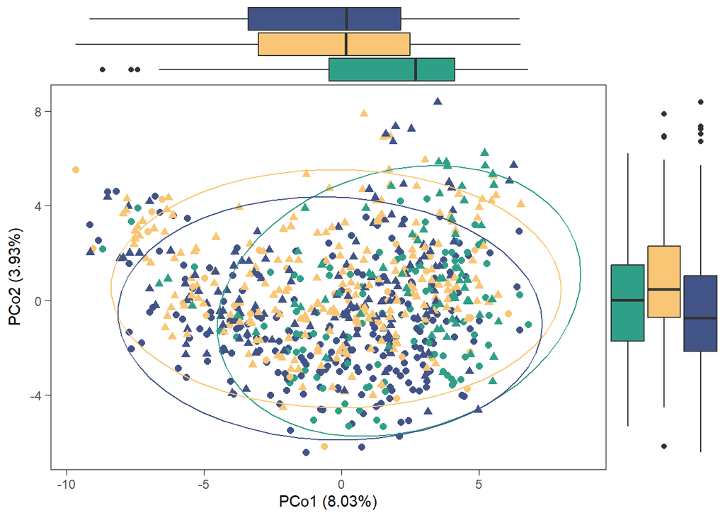

```r
p <- pca_plot_custom(filt_colon_genus_tab,
                                 filt_colon_genus_taxa,
                                 filt_colon_genus_metadata,
                                 show_boxplots = TRUE,
                                 variable = "Group", size=2,
                                 show_legend= FALSE)

# save the results
pca_plots_list[[paste(segment,level,"custom")]] <- p

# see the results
p
```

#### 3.3.2.1 Saving results

```r
write.xlsx(pairwise_aitchison_raw[[paste(level, segment)]],
           file = file.path(path,
           paste0("beta_diversity_results_", segment,".xlsx")))
```

### 3.3.3 Supplementary analysis

#### 3.3.3.1 Genus level

```r
level="genus"
```

##### 3.3.3.1.1 Bray-Curtis

**PERMANOVA**

```r
pairwise_df <- filt_colon_genus_tab %>% column_to_rownames("SeqID") %>% t()

# main effect
pp_main <- pairwise.adonis(pairwise_df,
                           filt_colon_genus_metadata$Group,
                           covariate = filt_colon_genus_metadata$Country,
                           patients = filt_colon_genus_metadata$Patient,
                           sim.method = "bray", p.adjust.m="BH")

# interaction
pp_int <- pairwise.adonis(pairwise_df,
                          filt_colon_genus_metadata$Group,
                          covariate = filt_colon_genus_metadata$Country,
                          patients = filt_colon_genus_metadata$Patient,
                          interaction = TRUE, sim.method = "bray", p.adjust.m="BH")

# tidy the results
pp_factor <- pp_main[[1]]
pp_cov <- pp_main[[2]]
pp_fac.cov <- pp_int[[3]]

cols <- c("pairs","Df","SumsOfSqs", "F.Model","R2","p.value", "p.adjusted", "sig")
colnames(pp_factor) <- cols; colnames(pp_cov) <- cols; colnames(pp_fac.cov) <- cols;

# save raw results
supplements_beta[[paste("bray",level,segment)]] <- rbind(pp_factor,pp_cov,pp_fac.cov)
```

```r
# see the results
knitr::kable(pp_factor,digits = 3,caption = "PERMANOVA, GROUP separation")
```

PERMANOVA, GROUP separation

| pairs | Df | SumsOfSqs | F.Model | R2 | p.value | p.adjusted | sig |
| --- | --- | --- | --- | --- | --- | --- | --- |
| pre_ltx vs healthy | 1 | 2.119 | 10.732 | 0.024 | 0.001 | 0.001 | *** |
| pre_ltx vs post_ltx | 1 | 1.307 | 6.239 | 0.010 | 0.001 | 0.001 | *** |
| post_ltx vs healthy | 1 | 3.286 | 17.150 | 0.031 | 0.001 | 0.001 | *** |

```r
knitr::kable(pp_cov,digits = 3,caption = "PERMANOVA, COUNTRY separation")
```

PERMANOVA, COUNTRY separation

| pairs | Df | SumsOfSqs | F.Model | R2 | p.value | p.adjusted | sig |
| --- | --- | --- | --- | --- | --- | --- | --- |
| pre_ltx vs healthy , Country | 1 | 2.862 | 14.497 | 0.033 | 0.001 | 0.001 | *** |
| pre_ltx vs post_ltx , Country | 1 | 6.618 | 31.603 | 0.049 | 0.001 | 0.001 | *** |
| post_ltx vs healthy , Country | 1 | 5.496 | 28.682 | 0.052 | 0.001 | 0.001 | *** |

```r
knitr::kable(pp_fac.cov,digits = 3,caption = "PERMANOVA, INTERACTION GROUP:Country")
```

PERMANOVA, INTERACTION GROUP:Country

| pairs | Df | SumsOfSqs | F.Model | R2 | p.value | p.adjusted | sig |
| --- | --- | --- | --- | --- | --- | --- | --- |
| pre_ltx vs healthy : Country | 1 | 0.783 | 3.993 | 0.009 | 0.012 | 0.018 | * |
| pre_ltx vs post_ltx : Country | 1 | 0.562 | 2.691 | 0.004 | 0.112 | 0.112 |  |
| post_ltx vs healthy : Country | 1 | 0.998 | 5.252 | 0.009 | 0.002 | 0.006 | ** |

Interaction check

```r
interaction_sig <- pp_fac.cov$pairs[pp_fac.cov$p.adjusted < 0.05]

for (i in 1:length(interaction_sig)){
  group1 <- unlist(strsplit(interaction_sig[i],split = " vs "))[1]
  group2 <- unlist(strsplit(interaction_sig[i],split = " vs "))[2]
  group2 <- unlist(strsplit(group2,split = " : "))[1]

  result_list <- adonis_postanalysis(x=pairwise_df,
                      factors = filt_colon_genus_metadata$Group,
                      covariate = filt_colon_genus_metadata$Country,
                      patients = filt_colon_genus_metadata$Patient,
                      group1 = group1,
                      group2 = group2,
                      sim.method = 'bray')
  print(result_list)
}
```

```
$pre_ltx_healthy_CZ
Permutation test for adonis under reduced model
Terms added sequentially (first to last)
Permutation: supplied matrix
Number of permutations: 999

adonis2(formula = x1 ~ Fac, data = x2, permutations = perm)
          Df SumOfSqs     R2      F Pr(>F) p.adjusted
Fac        1    0.680 0.0271 3.7602   0.05       0.05
Residual 135   24.413 0.9729
Total    136   25.093 1.0000

$pre_ltx_healthy_NO
Permutation test for adonis under reduced model
Terms added sequentially (first to last)
Permutation: supplied matrix
Number of permutations: 999

adonis2(formula = x1 ~ Fac, data = x2, permutations = perm)
          Df SumOfSqs      R2      F Pr(>F) p.adjusted
Fac        1    2.222 0.03858 10.915  0.001  0.0013333
Residual 272   55.360 0.96142
Total    273   57.582 1.00000

$pre_ltx_CZ_vs_NO
Permutation test for adonis under reduced model
Terms added sequentially (first to last)
Permutation: supplied matrix
Number of permutations: 999

adonis2(formula = x1 ~ Cov, data = x2, permutations = perm)
          Df SumOfSqs     R2      F Pr(>F) p.adjusted
Cov        1    2.166 0.0386 9.9564  0.001  0.0013333
Residual 248   53.948 0.9614
Total    249   56.114 1.0000

$healthy_CZ_vs_NO
Permutation test for adonis under reduced model
Terms added sequentially (first to last)
Permutation: supplied matrix
```

[output cut: 40 more lines]

```
Cov        1    5.014 0.06639 24.748  0.001      0.001
Residual 348   70.512 0.93361
Total    349   75.526 1.00000

$healthy_CZ_vs_NO
Permutation test for adonis under reduced model
Terms added sequentially (first to last)
Permutation: supplied matrix
Number of permutations: 999

adonis2(formula = x1 ~ Cov, data = x2, permutations = perm)
          Df SumOfSqs      R2      F Pr(>F) p.adjusted
Cov        1   1.4791 0.05417 9.1064  0.001      0.001
Residual 159  25.8258 0.94583
Total    160  27.3049 1.00000
```

**Plots**

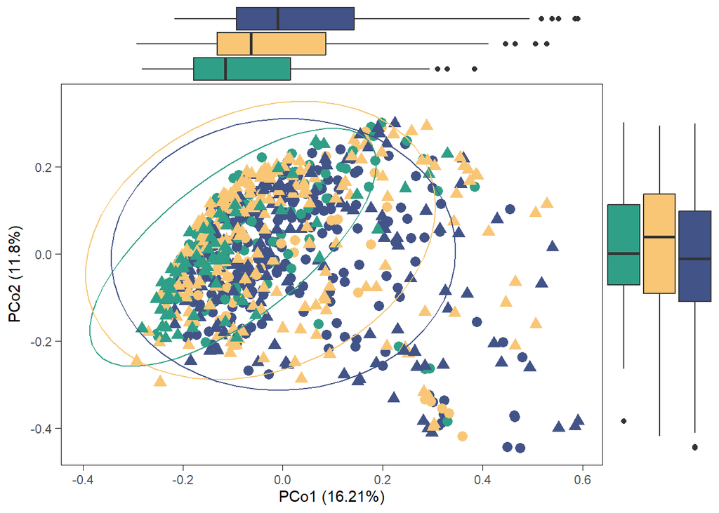

```r
p <- pca_plot_custom(filt_colon_genus_tab,
                                 filt_colon_genus_taxa,
                                 filt_colon_genus_metadata,
                                 measure = "bray",
                                 show_boxplots = TRUE,
                                 variable = "Group", size=3, show_legend= FALSE)

# save the results
supplements_beta[[paste("PCoA bray",level,segment)]] <- p

# see the results
p
```

##### 3.3.3.1.2 Jaccard

**PERMANOVA**

```r
pairwise_df <- filt_colon_genus_tab %>% column_to_rownames("SeqID") %>% t()

# main effect
pp_main <- pairwise.adonis(pairwise_df,
                           filt_colon_genus_metadata$Group,
                           covariate = filt_colon_genus_metadata$Country,
                           patients = filt_colon_genus_metadata$Patient,
                           sim.method = "jaccard", p.adjust.m="BH")

# interaction
pp_int <- pairwise.adonis(pairwise_df,
                          filt_colon_genus_metadata$Group,
                          covariate = filt_colon_genus_metadata$Country,
                          patients = filt_colon_genus_metadata$Patient,
                          interaction = TRUE, sim.method = "jaccard", p.adjust.m="BH")

# tidy the results
pp_factor <- pp_main[[1]]
pp_cov <- pp_main[[2]]
pp_fac.cov <- pp_int[[3]]

cols <- c("pairs","Df","SumsOfSqs", "F.Model","R2","p.value", "p.adjusted", "sig")
colnames(pp_factor) <- cols; colnames(pp_cov) <- cols; colnames(pp_fac.cov) <- cols;

# save raw results
supplements_beta[[paste("jaccard",level,segment)]] <- rbind(pp_factor,
                                                            pp_cov,
                                                            pp_fac.cov)
```

```r
# see the results
knitr::kable(pp_factor,digits = 3,caption = "PERMANOVA, GROUP separation")
```

PERMANOVA, GROUP separation

| pairs | Df | SumsOfSqs | F.Model | R2 | p.value | p.adjusted | sig |
| --- | --- | --- | --- | --- | --- | --- | --- |
| pre_ltx vs healthy | 1 | 2.225 | 7.844 | 0.018 | 0.001 | 0.002 | ** |
| pre_ltx vs post_ltx | 1 | 1.382 | 4.680 | 0.007 | 0.002 | 0.002 | ** |
| post_ltx vs healthy | 1 | 3.371 | 12.044 | 0.022 | 0.001 | 0.002 | ** |

```r
knitr::kable(pp_cov,digits = 3,caption = "PERMANOVA, COUNTRY separation")
```

PERMANOVA, COUNTRY separation

| pairs | Df | SumsOfSqs | F.Model | R2 | p.value | p.adjusted | sig |
| --- | --- | --- | --- | --- | --- | --- | --- |
| pre_ltx vs healthy , Country | 1 | 3.013 | 10.622 | 0.025 | 0.001 | 0.001 | *** |
| pre_ltx vs post_ltx , Country | 1 | 6.474 | 21.918 | 0.035 | 0.001 | 0.001 | *** |
| post_ltx vs healthy , Country | 1 | 5.595 | 19.994 | 0.037 | 0.001 | 0.001 | *** |

```r
knitr::kable(pp_fac.cov,digits = 3,caption = "PERMANOVA, INTERACTION GROUP:Country")
```

PERMANOVA, INTERACTION GROUP:Country

| pairs | Df | SumsOfSqs | F.Model | R2 | p.value | p.adjusted | sig |
| --- | --- | --- | --- | --- | --- | --- | --- |
| pre_ltx vs healthy : Country | 1 | 0.939 | 3.330 | 0.008 | 0.010 | 0.015 | * |
| pre_ltx vs post_ltx : Country | 1 | 0.696 | 2.362 | 0.004 | 0.163 | 0.163 |  |
| post_ltx vs healthy : Country | 1 | 1.134 | 4.078 | 0.008 | 0.001 | 0.003 | ** |

Interaction check

```r
interaction_sig <- pp_fac.cov$pairs[pp_fac.cov$p.adjusted < 0.05]

for (i in 1:length(interaction_sig)){
  group1 <- unlist(strsplit(interaction_sig[i],split = " vs "))[1]
  group2 <- unlist(strsplit(interaction_sig[i],split = " vs "))[2]
  group2 <- unlist(strsplit(group2,split = " : "))[1]

  result_list <- adonis_postanalysis(x=pairwise_df,
                      factors = filt_colon_genus_metadata$Group,
                      covariate = filt_colon_genus_metadata$Country,
                      patients = filt_colon_genus_metadata$Patient,
                      group1 = group1,
                      group2 = group2,
                      sim.method = 'jaccard')
  print(result_list)
}
```

```
$pre_ltx_healthy_CZ
Permutation test for adonis under reduced model
Terms added sequentially (first to last)
Permutation: supplied matrix
Number of permutations: 999

adonis2(formula = x1 ~ Fac, data = x2, permutations = perm)
          Df SumOfSqs      R2      F Pr(>F) p.adjusted
Fac        1    0.759 0.02074 2.8587  0.061      0.061
Residual 135   35.842 0.97926
Total    136   36.601 1.00000

$pre_ltx_healthy_NO
Permutation test for adonis under reduced model
Terms added sequentially (first to last)
Permutation: supplied matrix
Number of permutations: 999

adonis2(formula = x1 ~ Fac, data = x2, permutations = perm)
          Df SumOfSqs      R2      F Pr(>F) p.adjusted
Fac        1    2.405 0.02957 8.2869  0.001  0.0013333
Residual 272   78.937 0.97043
Total    273   81.342 1.00000

$pre_ltx_CZ_vs_NO
Permutation test for adonis under reduced model
Terms added sequentially (first to last)
Permutation: supplied matrix
Number of permutations: 999

adonis2(formula = x1 ~ Cov, data = x2, permutations = perm)
          Df SumOfSqs      R2      F Pr(>F) p.adjusted
Cov        1    2.196 0.02856 7.2916  0.001  0.0013333
Residual 248   74.696 0.97144
Total    249   76.892 1.00000

$healthy_CZ_vs_NO
Permutation test for adonis under reduced model
Terms added sequentially (first to last)
Permutation: supplied matrix
```

[output cut: 40 more lines]

```
Cov        1    4.974 0.04696 17.147  0.001      0.001
Residual 348  100.952 0.95304
Total    349  105.926 1.00000

$healthy_CZ_vs_NO
Permutation test for adonis under reduced model
Terms added sequentially (first to last)
Permutation: supplied matrix
Number of permutations: 999

adonis2(formula = x1 ~ Cov, data = x2, permutations = perm)
          Df SumOfSqs      R2      F Pr(>F) p.adjusted
Cov        1    1.756 0.04196 6.9641  0.001      0.001
Residual 159   40.083 0.95804
Total    160   41.839 1.00000
```

**Plots**

*Custom*

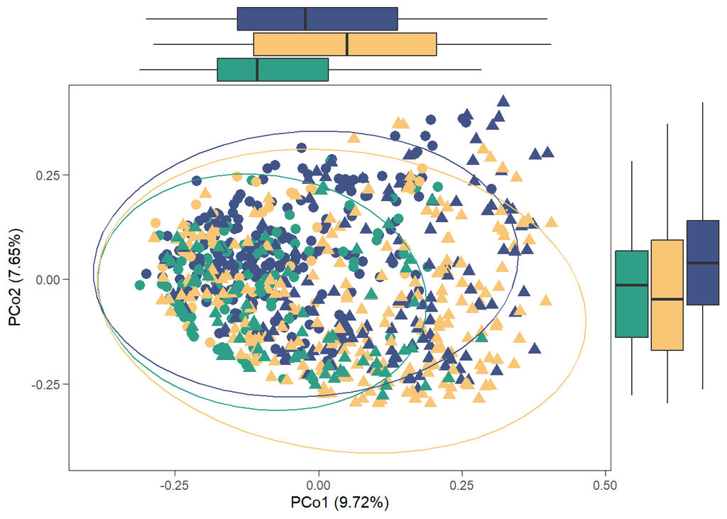

```r
p <- pca_plot_custom(filt_colon_genus_tab,
                                 filt_colon_genus_taxa,
                                 filt_colon_genus_metadata,
                                 measure = "jaccard",
                                 show_boxplots = TRUE,
                                 variable = "Group", size=3, show_legend= FALSE)

# save the results
supplements_beta[[paste("PCoA jaccard",level,segment)]] <- p

# see the results
p
```

#### 3.3.3.2 ASV level

```r
level="ASV"
```

##### 3.3.3.2.1 Aitchison

```r
# preparing data frame
pairwise_df <- filt_colon_asv_tab %>% column_to_rownames("SeqID") %>% t()

# main effect
pp_main <- pairwise.adonis(x=pairwise_df,
                          filt_colon_metadata$Group,
                           covariate = filt_colon_metadata$Country,
                           sim.method = "robust.aitchison",
                           p.adjust.m="BH",
                           patients = filt_colon_metadata$Patient)

# interaction
pp_int <- pairwise.adonis(pairwise_df,filt_colon_metadata$Group,
                          covariate = filt_colon_metadata$Country,
                          interaction = TRUE,
                          sim.method = "robust.aitchison",
                          p.adjust.m="BH",
                          patients = filt_colon_metadata$Patient)

pp_factor <- pp_main[[1]]
pp_cov <- pp_main[[2]]
pp_fac.cov <- pp_int[[3]]

cols <- c("pairs","Df","SumsOfSqs", "F.Model","R2","p.value", "p.adjusted", "sig")
colnames(pp_factor) <- cols; colnames(pp_cov) <- cols; colnames(pp_fac.cov) <- cols;

# save raw results
supplements_beta[[paste("aitchison",level,segment)]] <- rbind(pp_factor,
                                                            pp_cov,
                                                            pp_fac.cov)

# see the results
pp_factor
```

```
                pairs Df SumsOfSqs   F.Model          R2 p.value p.adjusted sig
1  pre_ltx vs healthy  1  1711.535  7.089160 0.016854638   0.001     0.0015  **
2 pre_ltx vs post_ltx  1   799.824  3.515868 0.005780561   0.023     0.0230   *
3 post_ltx vs healthy  1  2419.630 10.210591 0.019444444   0.001     0.0015  **
```

```r
pp_cov
```

```
                          pairs Df SumsOfSqs  F.Model         R2 p.value
1  pre_ltx vs healthy , Country  1  948.4242 3.928362 0.00933977   0.001
2 pre_ltx vs post_ltx , Country  1 1595.1673 7.012040 0.01152874   0.001
3 post_ltx vs healthy , Country  1 1870.9425 7.895186 0.01503512   0.001
  p.adjusted sig
1      0.001 ***
2      0.001 ***
3      0.001 ***
```

```r
pp_fac.cov
```

```
                          pairs Df SumsOfSqs  F.Model          R2 p.value
1  pre_ltx vs healthy : Country  1  571.9973 2.377204 0.005632842   0.086
2 pre_ltx vs post_ltx : Country  1  439.3379 1.934270 0.003175223   0.768
3 post_ltx vs healthy : Country  1  626.6210 2.652897 0.005035604   0.023
  p.adjusted sig
1      0.129
2      0.768
3      0.069
```

```r
# see the results
knitr::kable(pp_factor,digits = 3,caption = "PERMANOVA, GROUP separation")
```

PERMANOVA, GROUP separation

| pairs | Df | SumsOfSqs | F.Model | R2 | p.value | p.adjusted | sig |
| --- | --- | --- | --- | --- | --- | --- | --- |
| pre_ltx vs healthy | 1 | 1711.535 | 7.089 | 0.017 | 0.001 | 0.002 | ** |
| pre_ltx vs post_ltx | 1 | 799.824 | 3.516 | 0.006 | 0.023 | 0.023 | * |
| post_ltx vs healthy | 1 | 2419.630 | 10.211 | 0.019 | 0.001 | 0.002 | ** |

```r
knitr::kable(pp_cov,digits = 3,caption = "PERMANOVA, COUNTRY separation")
```

PERMANOVA, COUNTRY separation

| pairs | Df | SumsOfSqs | F.Model | R2 | p.value | p.adjusted | sig |
| --- | --- | --- | --- | --- | --- | --- | --- |
| pre_ltx vs healthy , Country | 1 | 948.424 | 3.928 | 0.009 | 0.001 | 0.001 | *** |
| pre_ltx vs post_ltx , Country | 1 | 1595.167 | 7.012 | 0.012 | 0.001 | 0.001 | *** |
| post_ltx vs healthy , Country | 1 | 1870.942 | 7.895 | 0.015 | 0.001 | 0.001 | *** |

```r
knitr::kable(pp_fac.cov,digits = 3,caption = "PERMANOVA, INTERACTION GROUP:Country")
```

PERMANOVA, INTERACTION GROUP:Country

| pairs | Df | SumsOfSqs | F.Model | R2 | p.value | p.adjusted | sig |
| --- | --- | --- | --- | --- | --- | --- | --- |
| pre_ltx vs healthy : Country | 1 | 571.997 | 2.377 | 0.006 | 0.086 | 0.129 |  |
| pre_ltx vs post_ltx : Country | 1 | 439.338 | 1.934 | 0.003 | 0.768 | 0.768 |  |
| post_ltx vs healthy : Country | 1 | 626.621 | 2.653 | 0.005 | 0.023 | 0.069 |  |

Interaction check

```r
interaction_sig <- pp_fac.cov$pairs[pp_fac.cov$p.adjusted < 0.05]

if (length(interaction_sig)>0){
 for (i in 1:length(interaction_sig)){
  group1 <- unlist(strsplit(interaction_sig[i],split = " vs "))[1]
  group2 <- unlist(strsplit(interaction_sig[i],split = " vs "))[2]
  group2 <- unlist(strsplit(group2,split = " : "))[1]

  result_list <- adonis_postanalysis(x=pairwise_df,
                      factors = filt_colon_metadata$Group,
                      covariate = filt_colon_metadata$Country,
                      group1 = group1,
                      group2 = group2,
                      patients = filt_colon_metadata$Patient)
  print(result_list)
}
}
```

**PCoA**

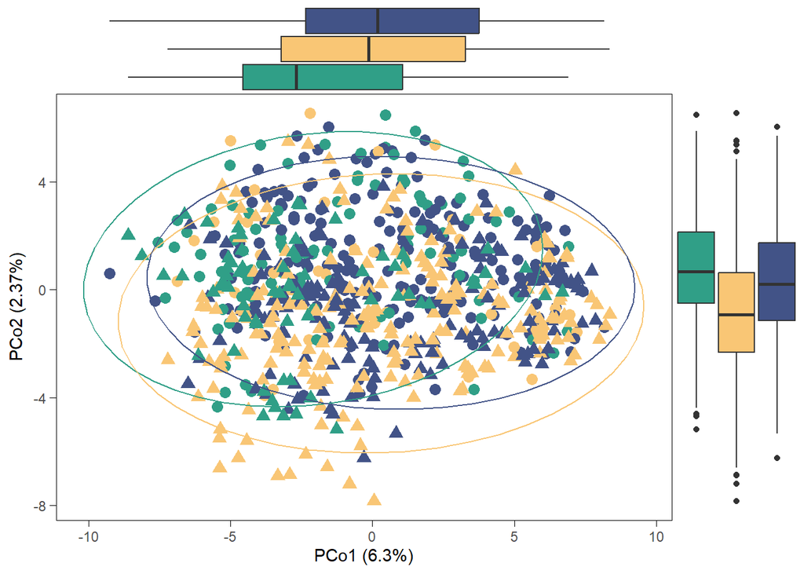

```r
p <- pca_plot_custom(filt_colon_asv_tab,
                           filt_colon_taxa_tab,
                           filt_colon_metadata,
                           show_boxplots = TRUE,
                           variable = "Group",
                           size=3,
                           show_legend= FALSE)

# save the results
supplements_beta[[paste("PCoA aitchison",level,segment)]] <- p

# see the results
p
```

##### 3.3.3.2.2 Bray-Curtis

**PERMANOVA**

```r
# preparing data frame
pairwise_df <- filt_colon_asv_tab %>% column_to_rownames("SeqID") %>% t()

# main effect
pp_main <- pairwise.adonis(pairwise_df,
                           filt_colon_metadata$Group,
                           covariate = filt_colon_metadata$Country,
                           patients = filt_colon_metadata$Patient,
                           sim.method = "bray", p.adjust.m="BH")

# interaction
pp_int <- pairwise.adonis(pairwise_df,
                          filt_colon_metadata$Group,
                          covariate = filt_colon_metadata$Country,
                          patients = filt_colon_metadata$Patient,
                          interaction = TRUE, sim.method = "bray", p.adjust.m="BH")

pp_factor <- pp_main[[1]]
pp_cov <- pp_main[[2]]
pp_fac.cov <- pp_int[[3]]

cols <- c("pairs","Df","SumsOfSqs", "F.Model","R2","p.value", "p.adjusted", "sig")
colnames(pp_factor) <- cols; colnames(pp_cov) <- cols; colnames(pp_fac.cov) <- cols;

# save raw results
supplements_beta[[paste("bray",level,segment)]] <- rbind(pp_factor,
                                                            pp_cov,
                                                            pp_fac.cov)
```

```r
# see the results
knitr::kable(pp_factor,digits = 3,caption = "PERMANOVA, GROUP separation")
```

PERMANOVA, GROUP separation

| pairs | Df | SumsOfSqs | F.Model | R2 | p.value | p.adjusted | sig |
| --- | --- | --- | --- | --- | --- | --- | --- |
| pre_ltx vs healthy | 1 | 3.090 | 9.636 | 0.023 | 0.001 | 0.001 | *** |
| pre_ltx vs post_ltx | 1 | 1.948 | 5.972 | 0.010 | 0.001 | 0.001 | *** |
| post_ltx vs healthy | 1 | 4.788 | 15.423 | 0.029 | 0.001 | 0.001 | *** |

```r
knitr::kable(pp_cov,digits = 3,caption = "PERMANOVA, COUNTRY separation")
```

PERMANOVA, COUNTRY separation

| pairs | Df | SumsOfSqs | F.Model | R2 | p.value | p.adjusted | sig |
| --- | --- | --- | --- | --- | --- | --- | --- |
| pre_ltx vs healthy , Country | 1 | 2.383 | 7.429 | 0.017 | 0.001 | 0.001 | *** |
| pre_ltx vs post_ltx , Country | 1 | 5.328 | 16.338 | 0.026 | 0.001 | 0.001 | *** |
| post_ltx vs healthy , Country | 1 | 4.912 | 15.825 | 0.029 | 0.001 | 0.001 | *** |

```r
knitr::kable(pp_fac.cov,digits = 3,caption = "PERMANOVA, INTERACTION GROUP:Country")
```

PERMANOVA, INTERACTION GROUP:Country

| pairs | Df | SumsOfSqs | F.Model | R2 | p.value | p.adjusted | sig |
| --- | --- | --- | --- | --- | --- | --- | --- |
| pre_ltx vs healthy : Country | 1 | 0.901 | 2.821 | 0.007 | 0.040 | 0.060 |  |
| pre_ltx vs post_ltx : Country | 1 | 0.830 | 2.551 | 0.004 | 0.131 | 0.131 |  |
| post_ltx vs healthy : Country | 1 | 1.362 | 4.417 | 0.008 | 0.003 | 0.009 | ** |

Interaction check

```r
interaction_sig <- pp_fac.cov$pairs[pp_fac.cov$p.adjusted < 0.05]

for (i in 1:length(interaction_sig)){
  group1 <- unlist(strsplit(interaction_sig[i],split = " vs "))[1]
  group2 <- unlist(strsplit(interaction_sig[i],split = " vs "))[2]
  group2 <- unlist(strsplit(group2,split = " : "))[1]

  result_list <- adonis_postanalysis(x=pairwise_df,
                      factors = filt_colon_metadata$Group,
                      covariate = filt_colon_metadata$Country,
                      group1 = group1,
                      group2 = group2,
                      patients = filt_colon_metadata$Patient,
                      sim.method = 'bray')
  print(result_list)
}
```

```
$post_ltx_healthy_CZ
Permutation test for adonis under reduced model
Terms added sequentially (first to last)
Permutation: supplied matrix
Number of permutations: 999

adonis2(formula = x1 ~ Fac, data = x2, permutations = perm)
          Df SumOfSqs      R2      F Pr(>F) p.adjusted
Fac        1    2.098 0.02219 6.8301  0.001      0.001
Residual 301   92.461 0.97781
Total    302   94.559 1.00000

$post_ltx_healthy_NO
Permutation test for adonis under reduced model
Terms added sequentially (first to last)
Permutation: supplied matrix
Number of permutations: 999

adonis2(formula = x1 ~ Fac, data = x2, permutations = perm)
          Df SumOfSqs      R2      F Pr(>F) p.adjusted
Fac        1    4.052 0.05993 13.068  0.001      0.001
Residual 205   63.559 0.94007
Total    206   67.611 1.00000

$post_ltx_CZ_vs_NO
Permutation test for adonis under reduced model
Terms added sequentially (first to last)
Permutation: supplied matrix
Number of permutations: 999

adonis2(formula = x1 ~ Cov, data = x2, permutations = perm)
          Df SumOfSqs      R2      F Pr(>F) p.adjusted
Cov        1    4.574 0.03999 14.456  0.001      0.001
Residual 347  109.796 0.96001
Total    348  114.370 1.00000

$healthy_CZ_vs_NO
Permutation test for adonis under reduced model
Terms added sequentially (first to last)
Permutation: supplied matrix
Number of permutations: 999

adonis2(formula = x1 ~ Cov, data = x2, permutations = perm)
          Df SumOfSqs      R2      F Pr(>F) p.adjusted
Cov        1    1.700 0.03547 5.8478  0.001      0.001
Residual 159   46.225 0.96453
Total    160   47.925 1.00000
```

**PCoA**

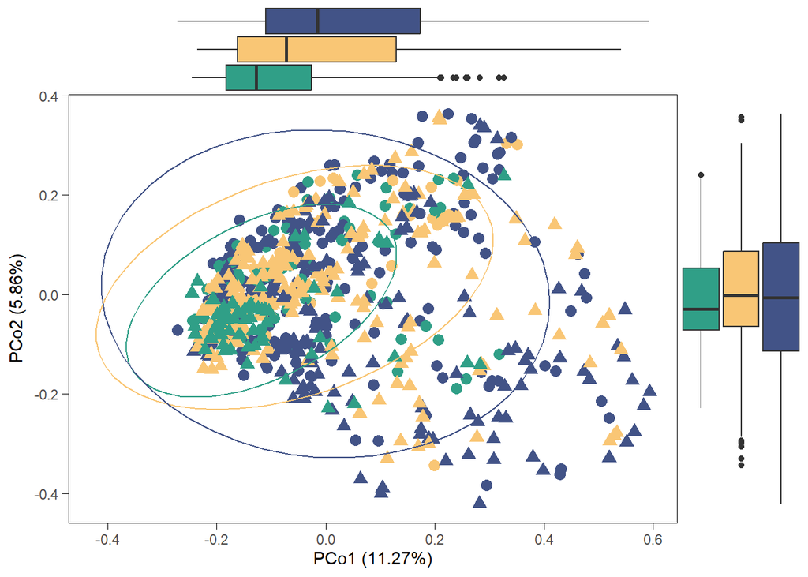

```r
p <- pca_plot_custom(filt_colon_asv_tab,
                     filt_colon_taxa_tab,
                     filt_colon_metadata,
                     measure = "bray",
                     show_boxplots = TRUE,
                     variable = "Group", size=3, show_legend= FALSE)

# save the results
supplements_beta[[paste("PCoA bray",level,segment)]] <- p

# see the results
p
```

##### 3.3.3.2.3 Jaccard

**PERMANOVA**

```r
# preparing data frame
pairwise_df <- filt_colon_asv_tab %>% column_to_rownames("SeqID") %>% t()

# main effect
pp_main <- pairwise.adonis(pairwise_df,
                           filt_colon_metadata$Group,
                           covariate = filt_colon_metadata$Country,
                           patients = filt_colon_metadata$Patient,
                           sim.method = "jaccard", p.adjust.m="BH")

# interaction
pp_int <- pairwise.adonis(pairwise_df,
                          filt_colon_metadata$Group,
                          covariate = filt_colon_metadata$Country,
                          patients = filt_colon_metadata$Patient,
                          interaction = TRUE, sim.method = "jaccard", p.adjust.m="BH")

pp_factor <- pp_main[[1]]
pp_cov <- pp_main[[2]]
pp_fac.cov <- pp_int[[3]]

cols <- c("pairs","Df","SumsOfSqs", "F.Model","R2","p.value", "p.adjusted", "sig")
colnames(pp_factor) <- cols; colnames(pp_cov) <- cols; colnames(pp_fac.cov) <- cols;

# save raw results
supplements_beta[[paste("jaccard",level,segment)]] <- rbind(pp_factor,
                                                            pp_cov,
                                                            pp_fac.cov)
```

```r
# see the results
knitr::kable(pp_factor,digits = 3,caption = "PERMANOVA, GROUP separation")
```

PERMANOVA, GROUP separation

| pairs | Df | SumsOfSqs | F.Model | R2 | p.value | p.adjusted | sig |
| --- | --- | --- | --- | --- | --- | --- | --- |
| pre_ltx vs healthy | 1 | 2.453 | 6.302 | 0.015 | 0.001 | 0.001 | *** |
| pre_ltx vs post_ltx | 1 | 1.695 | 4.312 | 0.007 | 0.001 | 0.001 | *** |
| post_ltx vs healthy | 1 | 3.721 | 9.734 | 0.018 | 0.001 | 0.001 | *** |

```r
knitr::kable(pp_cov,digits = 3,caption = "PERMANOVA, COUNTRY separation")
```

PERMANOVA, COUNTRY separation

| pairs | Df | SumsOfSqs | F.Model | R2 | p.value | p.adjusted | sig |
| --- | --- | --- | --- | --- | --- | --- | --- |
| pre_ltx vs healthy , Country | 1 | 2.005 | 5.151 | 0.012 | 0.001 | 0.001 | *** |
| pre_ltx vs post_ltx , Country | 1 | 4.185 | 10.649 | 0.017 | 0.001 | 0.001 | *** |
| post_ltx vs healthy , Country | 1 | 3.933 | 10.288 | 0.020 | 0.001 | 0.001 | *** |

```r
knitr::kable(pp_fac.cov,digits = 3,caption = "PERMANOVA, INTERACTION GROUP:Country")
```

PERMANOVA, INTERACTION GROUP:Country

| pairs | Df | SumsOfSqs | F.Model | R2 | p.value | p.adjusted | sig |
| --- | --- | --- | --- | --- | --- | --- | --- |
| pre_ltx vs healthy : Country | 1 | 0.906 | 2.336 | 0.006 | 0.086 | 0.129 |  |
| pre_ltx vs post_ltx : Country | 1 | 0.862 | 2.199 | 0.004 | 0.291 | 0.291 |  |
| post_ltx vs healthy : Country | 1 | 1.291 | 3.393 | 0.006 | 0.004 | 0.012 | * |

Interaction check

```r
interaction_sig <- pp_fac.cov$pairs[pp_fac.cov$p.adjusted < 0.05]

for (i in 1:length(interaction_sig)){
  group1 <- unlist(strsplit(interaction_sig[i],split = " vs "))[1]
  group2 <- unlist(strsplit(interaction_sig[i],split = " vs "))[2]
  group2 <- unlist(strsplit(group2,split = " : "))[1]

  result_list <- adonis_postanalysis(x=pairwise_df,
                      factors = filt_colon_metadata$Group,
                      covariate = filt_colon_metadata$Country,
                      patients = filt_colon_metadata$Patient,
                      group1 = group1,
                      group2 = group2,
                      sim.method = 'jaccard')
  print(result_list)
}
```

```
$post_ltx_healthy_CZ
Permutation test for adonis under reduced model
Terms added sequentially (first to last)
Permutation: supplied matrix
Number of permutations: 999

adonis2(formula = x1 ~ Fac, data = x2, permutations = perm)
          Df SumOfSqs      R2      F Pr(>F) p.adjusted
Fac        1    1.758 0.01512 4.6216  0.001      0.001
Residual 301  114.465 0.98488
Total    302  116.223 1.00000

$post_ltx_healthy_NO
Permutation test for adonis under reduced model
Terms added sequentially (first to last)
Permutation: supplied matrix
Number of permutations: 999

adonis2(formula = x1 ~ Fac, data = x2, permutations = perm)
          Df SumOfSqs      R2      F Pr(>F) p.adjusted
Fac        1    3.254 0.04003 8.5476  0.001      0.001
Residual 205   78.052 0.95997
Total    206   81.306 1.00000

$post_ltx_CZ_vs_NO
Permutation test for adonis under reduced model
Terms added sequentially (first to last)
Permutation: supplied matrix
Number of permutations: 999

adonis2(formula = x1 ~ Cov, data = x2, permutations = perm)
          Df SumOfSqs      R2      F Pr(>F) p.adjusted
Cov        1     3.68 0.02673 9.5297  0.001      0.001
Residual 347   134.00 0.97327
Total    348   137.68 1.00000

$healthy_CZ_vs_NO
Permutation test for adonis under reduced model
Terms added sequentially (first to last)
Permutation: supplied matrix
Number of permutations: 999

adonis2(formula = x1 ~ Cov, data = x2, permutations = perm)
          Df SumOfSqs     R2      F Pr(>F) p.adjusted
Cov        1    1.544 0.0257 4.1941  0.001      0.001
Residual 159   58.516 0.9743
Total    160   60.059 1.0000
```

**PCoA**

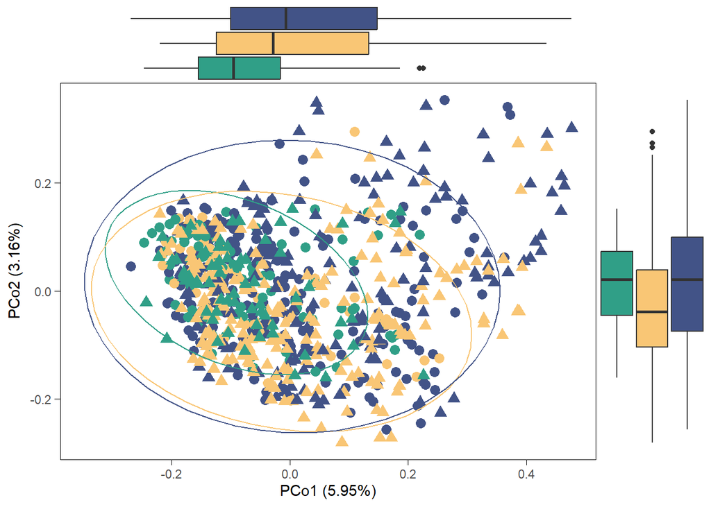

```r
p <- pca_plot_custom(filt_colon_asv_tab,
                     filt_colon_taxa_tab,
                     filt_colon_metadata,
                     measure = "jaccard",
                     show_boxplots = TRUE,
                     variable = "Group", size=3, show_legend= FALSE)

# save the results
supplements_beta[[paste("PCoA jaccard",level,segment)]] <- p

# see the results
p
```

#### 3.3.3.3 Saving results

```r
write.xlsx(supplements_beta[!grepl("PCoA",names(supplements_beta))],
           file = file.path(path,
           paste0("supplements_beta_diversity_", segment,".xlsx")))
```

## 3.4 Univariate Analysis

Using two DAA tools - linDA and Maaslin2. Only the intersection of sets selected by each tool was shown to minimize false positives. Taxa with a significant interaction effect were excluded based on individual post-hoc analysis of the Czech and Norwegian cohorts. Only taxa with significant log fold change that showed the same change direction in both countries were retained.

Main analysis is performed at genus level. In supplementary analysis, it is performed at ASV and phylum levels.

### 3.4.1 Main analysis

```r
level="genus"
```

```r
# needed paths
path = "../results/Q1/univariate_analysis"
path_maaslin=file.path("../intermediate_files/maaslin/Q1",level)

# variables
raw_linda_results_genus[[segment]] <- list()
linda_results_genus[[segment]] <- list()

# country and interaction problems
list_country_union <- list()
list_venns <- list()

# workbook for final df
wb <- createWorkbook()

# PSC effect
psc_effect <- list()
```

#### 3.4.1.1 Genus level

```r
level="genus"
```

Aggregate taxa

```r
genus_data <- aggregate_taxa(colon_asv_tab,
                             colon_taxa_tab,
                             taxonomic_level = level)

colon_genus_tab <- genus_data[[1]]
colon_genus_taxa_tab <- genus_data[[2]]

colon_genus_asv_taxa_tab <- create_asv_taxa_table(colon_genus_tab,
                                                  colon_genus_taxa_tab)
```

##### 3.4.1.1.1 pre_ltx vs healthy

###### 3.4.1.1.1.1 linDA

```r
group <- c("healthy","pre_ltx")
comparison_name <- paste0(group[1], " vs ",group[2])
```

```r
# prepare the data
linda_data <- binomial_prep(colon_genus_tab,
                            colon_genus_taxa_tab,
                            colon_metadata,
                            group, usage="linDA")
```

```
Removing 135 ASV(s)
```

```
Removing 10 ASV(s)
```

```r
filt_colon_uni_data <- linda_data[[1]]
filt_colon_uni_taxa <- linda_data[[2]]
filt_colon_uni_metadata <- linda_data[[3]]

# fit the model
linda.obj <- linda(filt_colon_uni_data,
                   filt_colon_uni_metadata,
                   formula = '~ Group * Country + (1|Patient)')
```

```
0  features are filtered!
The filtered data has  411  samples and  148  features will be tested!
Imputation approach is used.
Fit linear mixed effects models ...
Completed.
```

```r
linda.output <- linda.obj$output
linda.output <- linda_renaming(linda.output, group)

# save the results
group1 <- paste0(group[1], " vs ","Group",group[2])
group2 <- paste0(group[1], " , ",group[2], " - CZ vs NO")
group3 <- paste0(group[1], " vs ","Group",group[2], ":CountryNO")


for (grp in c(group1,group2,group3)){
  raw_linda_results_genus[[segment]][[grp]] <-
    rawlinda.df(linda.output,
                grp,
                filt_colon_uni_data,
                filt_colon_uni_taxa)

  linda_results_genus[[segment]][[grp]] <-
    linda.df(linda.output,
             grp,
             filt_colon_uni_data,
             filt_colon_uni_taxa)
}
```

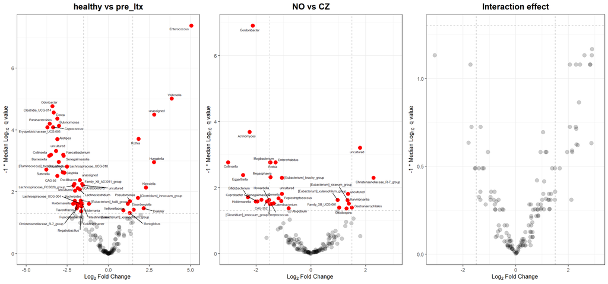

```r
# volcano plot
volcano_1 <- volcano_plot_linda(linda.output, group1,
                                taxa_table = filt_colon_uni_taxa) +
            ggtitle(paste(group,collapse=" vs "))

volcano_2  <- volcano_plot_linda(linda.output, group2,
                                taxa_table = filt_colon_uni_taxa) +
            ggtitle("NO vs CZ")

volcano_3 <- volcano_plot_linda(linda.output, group3,
                                taxa_table = filt_colon_uni_taxa) +
            ggtitle("Interaction effect")

volcano <- ggarrange(volcano_1,volcano_2,volcano_3, ncol=3)

# see the plot
volcano
```

###### 3.4.1.1.1.2 MaAsLin2

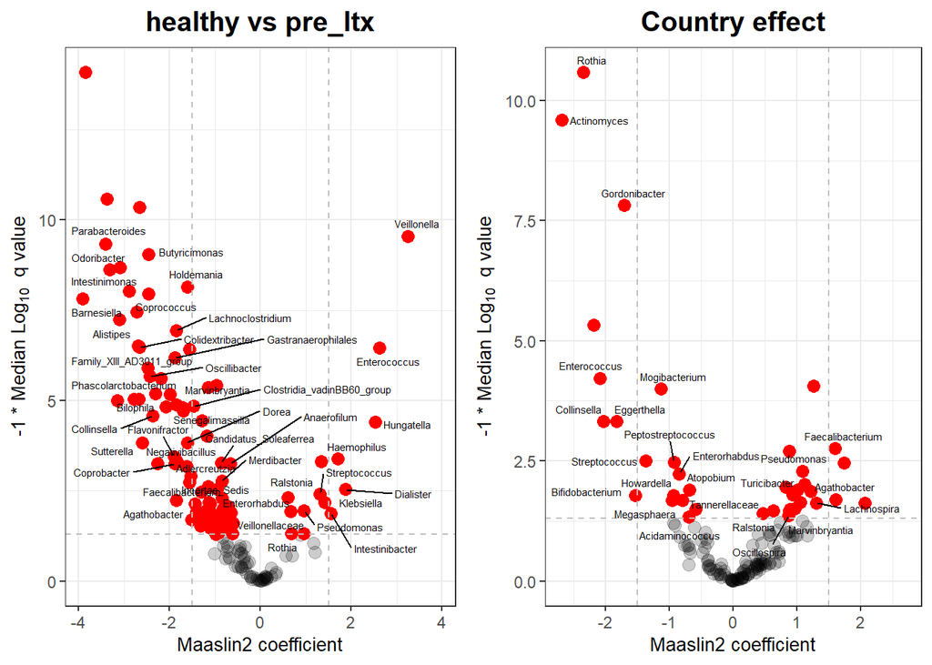

```r
volcano1 <- volcano_plot_maaslin(fit_data,filt_colon_uni_taxa) +
            ggtitle(paste(group[1], "vs", group[2]))

volcano2 <- volcano_plot_maaslin(fit_data,filt_colon_uni_taxa,variable="Country") +
            ggtitle("Country effect")

volcano <- ggarrange(volcano1,volcano2, ncol=2)
volcano
```

###### 3.4.1.1.1.3 Group - Intersection

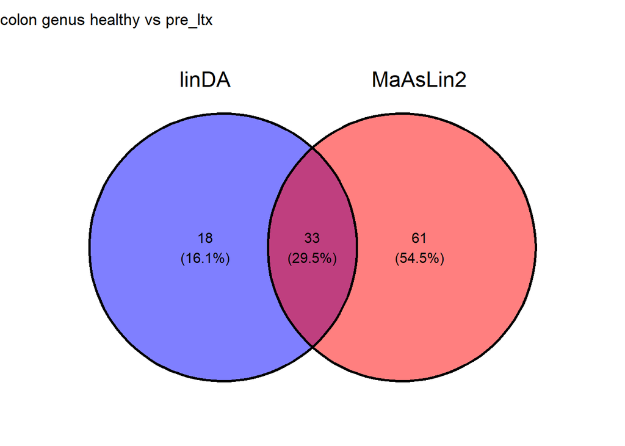

```r
intersection_results <- group_intersection(group, list_intersections, list_venns,
                                           linda.output, fit_data,
                                           raw_linda_results_genus,
                                           segment = segment,
                                           level=level)

list_intersections <- intersection_results[[1]]
list_venns <- intersection_results[[2]]
venn <- intersection_results[[3]]

# show the results
venn
```

###### 3.4.1.1.1.4 Interaction effect

```r
list_interaction_significant <- country_interaction(group,
                                                    linda.output,
                                                    list_intersections,
                                          filt_colon_uni_data,
                                          filt_colon_uni_metadata,
                                          segment=segment,
                                          level=level)

# see the result
## significant interaction effect
list_interaction_significant[[1]]
```

```r
## results for czech cohort
list_interaction_significant[[2]]
```

```
[1] NA
```

```r
## results for norwegian cohort
list_interaction_significant[[3]]
```

```
[1] NA
```

Removing problematic taxa

```r
list_intersections <- removing_interaction_problems(group,
                                                    list_interaction_significant,
                                                    list_intersections,
                                                    segment=segment,
                                                    level=level)
```

###### 3.4.1.1.1.5 Basic statistics

```r
uni_df <-  merge(basic_univariate_statistics(linda_data,group),
                 raw_linda_results_genus[[segment]][[group1]],
                 by="SeqID",all=TRUE)
```

```
[1] "healthy"
[1] "pre_ltx"
[1] "healthy"
[1] "pre_ltx"
```

```r
uni_df[["final_sig"]] <- uni_df$SeqID %in% list_intersections[[paste(segment,level,comparison_name)]][["SeqID"]]
uni_statistics[[segment]][[paste(level,comparison_name)]] <- uni_df

# for comparison
new_name <- comparison_name
addWorksheet(wb, sheetName = new_name)
writeData(wb, sheet = new_name, uni_df, rowNames=FALSE)
```

##### 3.4.1.1.2 pre_ltx vs post_ltx

```r
group <- c("pre_ltx","post_ltx")
comparison_name <- paste0(group[1], " vs ",group[2])
```

###### 3.4.1.1.2.1 linDA

```r
# prepare the data
linda_data <- binomial_prep(colon_genus_tab,
                            colon_genus_taxa_tab,
                            colon_metadata,
                            group, usage="linDA")
```

```
Removing 17 ASV(s)
```

```
Removing 10 ASV(s)
```

```r
filt_colon_uni_data <- linda_data[[1]]
filt_colon_uni_taxa <- linda_data[[2]]
filt_colon_uni_metadata <- linda_data[[3]]

# fit the model
linda.obj <- linda(filt_colon_uni_data,
                   filt_colon_uni_metadata,
                   formula = '~ Group * Country + (1|Patient)')
```

```
0  features are filtered!
The filtered data has  600  samples and  130  features will be tested!
Imputation approach is used.
Fit linear mixed effects models ...
Completed.
```

```r
linda.output <- linda.obj$output
linda.output <- linda_renaming(linda.output, group)

# save the results
group1 <- paste0(group[1], " vs ","Group",group[2])
group2 <- paste0(group[1], " , ",group[2], " - CZ vs NO")
group3 <- paste0(group[1], " vs ","Group",group[2], ":CountryNO")

for (grp in c(group1,group2,group3)){
  raw_linda_results_genus[[segment]][[grp]] <-
    rawlinda.df(linda.output,
                grp,
                filt_colon_uni_data,
                filt_colon_uni_taxa)

  linda_results_genus[[segment]][[grp]] <-
    linda.df(linda.output,
             grp,
             filt_colon_uni_data,
             filt_colon_uni_taxa)
}
```

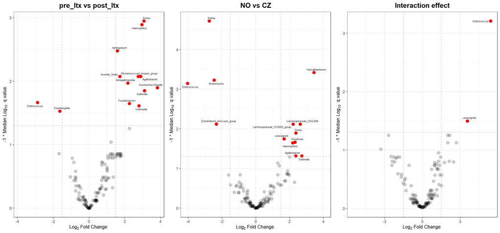

```r
# volcano plot
volcano_1 <- volcano_plot_linda(linda.output, group1,
                                taxa_table = filt_colon_uni_taxa) +
            ggtitle(paste(group,collapse=" vs "))

volcano_2  <- volcano_plot_linda(linda.output, group2,
                                taxa_table = filt_colon_uni_taxa) +
            ggtitle("NO vs CZ")

volcano_3 <- volcano_plot_linda(linda.output, group3,
                                taxa_table = filt_colon_uni_taxa) +
            ggtitle("Interaction effect")

volcano <- ggarrange(volcano_1,volcano_2,volcano_3, ncol=3)

# see the plot
volcano
```

###### 3.4.1.1.2.2 MaAsLin2

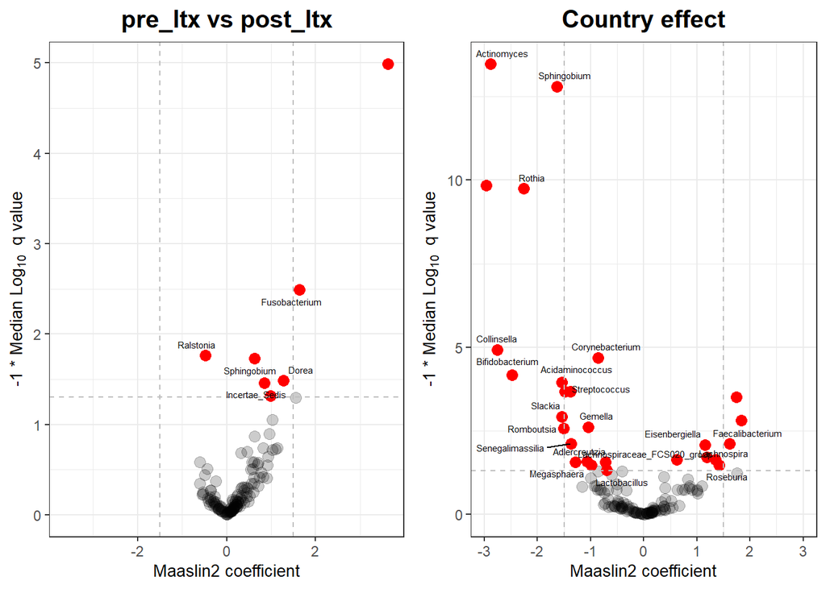

```r
volcano1 <- volcano_plot_maaslin(fit_data,filt_colon_uni_taxa) +
            ggtitle(paste(group[1], "vs", group[2]))

volcano2 <- volcano_plot_maaslin(fit_data,filt_colon_uni_taxa,variable="Country") +
            ggtitle("Country effect")

volcano <- ggarrange(volcano1,volcano2, ncol=2)
volcano
```

###### 3.4.1.1.2.3 Group - Intersection

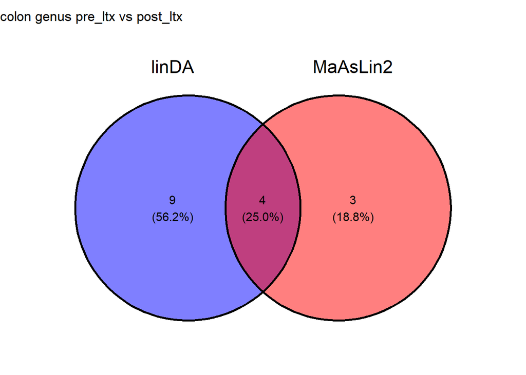

```r
intersection_results <- group_intersection(group,
                                           list_intersections,
                                           list_venns,
                                           linda.output, fit_data,
                                           raw_linda_results_genus,
                                           segment = segment,
                                           level=level)

list_intersections <- intersection_results[[1]]
list_venns <- intersection_results[[2]]
venn <- intersection_results[[3]]

# show the results
venn
```

###### 3.4.1.1.2.4 Interaction effect

```r
list_interaction_significant <- country_interaction(group,
                                                    linda.output,
                                                    list_intersections,
                                          filt_colon_uni_data,
                                          filt_colon_uni_metadata,
                                          segment=segment,
                                          level=level)

# see the result
## significant interaction effect
list_interaction_significant[[1]]
```

```r
## results for czech cohort
list_interaction_significant[[2]]
```

```
[1] NA
```

```r
## results for norwegian cohort
list_interaction_significant[[3]]
```

```
[1] NA
```

Removing problematic taxa

```r
list_intersections <- removing_interaction_problems(group,
                                                    list_interaction_significant,
                                                    list_intersections,
                                                    segment=segment,
                                                    level=level)
```

###### 3.4.1.1.2.5 Basic statistics

```r
uni_df <-  merge(basic_univariate_statistics(linda_data,group),
                 raw_linda_results_genus[[segment]][[group1]],
                 by="SeqID",all=TRUE)
```

```
[1] "pre_ltx"
[1] "post_ltx"
[1] "pre_ltx"
[1] "post_ltx"
```

```r
uni_df[["final_sig"]] <- uni_df$SeqID %in% list_intersections[[paste(segment,level,comparison_name)]][["SeqID"]]
uni_statistics[[segment]][[paste(level,comparison_name)]] <- uni_df

# for comparison
new_name <- comparison_name
addWorksheet(wb, sheetName = new_name)
writeData(wb, sheet = new_name, uni_df, rowNames=FALSE)
```

##### 3.4.1.1.3 post_ltx vs healthy

```r
group <- c("healthy","post_ltx")
comparison_name <- paste0(group[1], " vs ",group[2])
```

###### 3.4.1.1.3.1 linDA

```r
# prepare the data
linda_data <- binomial_prep(colon_genus_tab,
                            colon_genus_taxa_tab,
                            colon_metadata,group,
                            usage="linDA")
```

```
Removing 71 ASV(s)
```

```
Removing 5 ASV(s)
```

```r
filt_colon_uni_data <- linda_data[[1]]
filt_colon_uni_taxa <- linda_data[[2]]
filt_colon_uni_metadata <- linda_data[[3]]

# fit the model
linda.obj <- linda(filt_colon_uni_data,
                   filt_colon_uni_metadata,
                   formula = '~ Group * Country + (1|Patient)')
```

```
0  features are filtered!
The filtered data has  511  samples and  153  features will be tested!
Imputation approach is used.
Fit linear mixed effects models ...
Completed.
```

```r
linda.output <- linda.obj$output
linda.output <- linda_renaming(linda.output, group)

# save the results
group1 <- paste0(group[1], " vs ","Group",group[2])
group2 <- paste0(group[1], " , ",group[2], " - CZ vs NO")
group3 <- paste0(group[1], " vs ","Group",group[2], ":CountryNO")

for (grp in c(group1,group2,group3)){
  raw_linda_results_genus[[segment]][[grp]] <-
    rawlinda.df(linda.output,
                grp,
                filt_colon_uni_data,
                filt_colon_uni_taxa)

  linda_results_genus[[segment]][[grp]] <-
    linda.df(linda.output,
             grp,
             filt_colon_uni_data,
             filt_colon_uni_taxa)
}
```

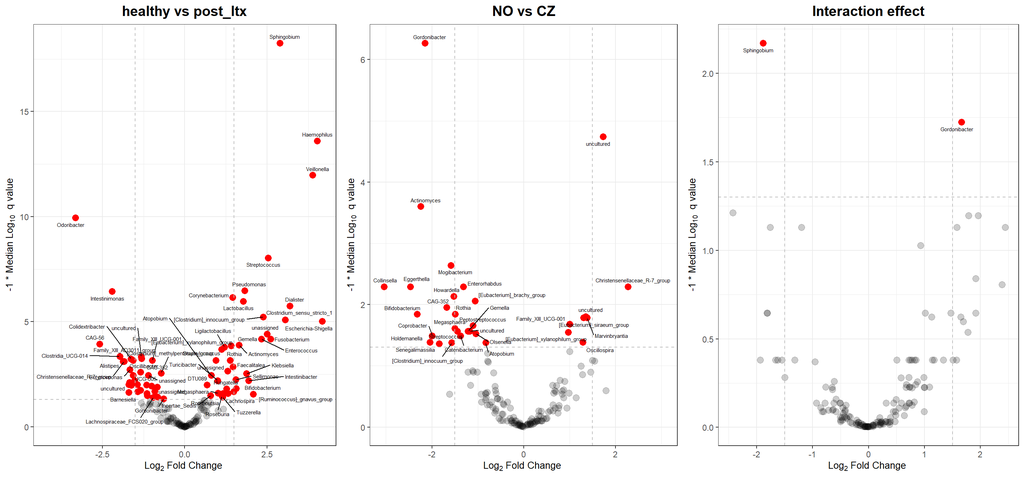

```r
# volcano plot
volcano_1 <- volcano_plot_linda(linda.output, group1,
                                taxa_table = filt_colon_uni_taxa) +
            ggtitle(paste(group,collapse=" vs "))

volcano_2  <- volcano_plot_linda(linda.output, group2,
                                taxa_table = filt_colon_uni_taxa) +
            ggtitle("NO vs CZ")

volcano_3 <- volcano_plot_linda(linda.output, group3,
                                taxa_table = filt_colon_uni_taxa) +
            ggtitle("Interaction effect")

volcano <- ggarrange(volcano_1,volcano_2,volcano_3, ncol=3)

# see the plot
volcano
```

###### 3.4.1.1.3.2 MaAsLin2

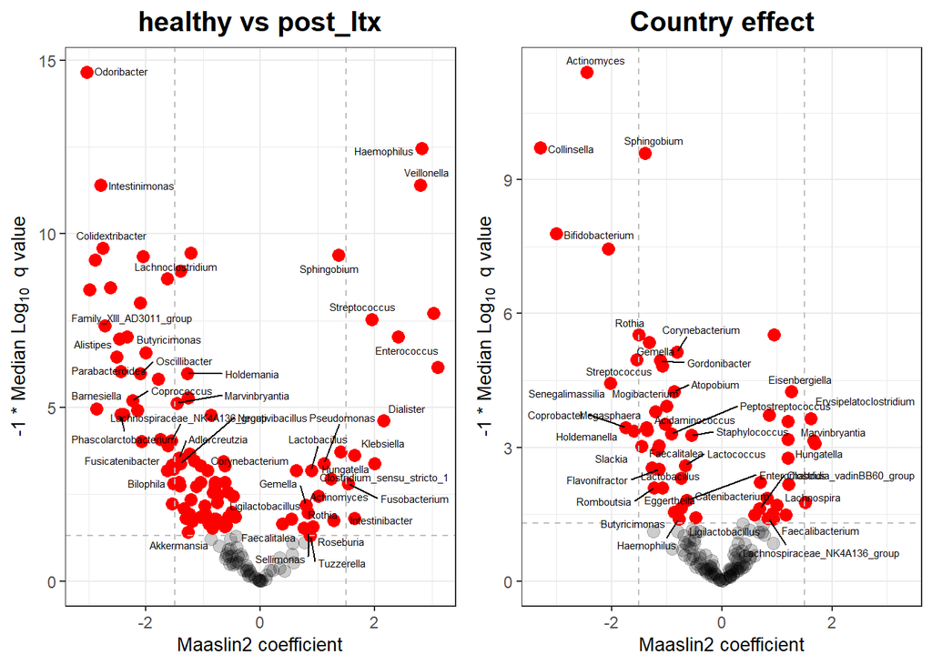

```r
volcano1 <- volcano_plot_maaslin(fit_data,filt_colon_uni_taxa) +
            ggtitle(paste(group[1], "vs", group[2]))

volcano2 <- volcano_plot_maaslin(fit_data,filt_colon_uni_taxa,variable="Country") +
            ggtitle("Country effect")

volcano <- ggarrange(volcano1,volcano2, ncol=2)
volcano
```

###### 3.4.1.1.3.3 Group - Intersection

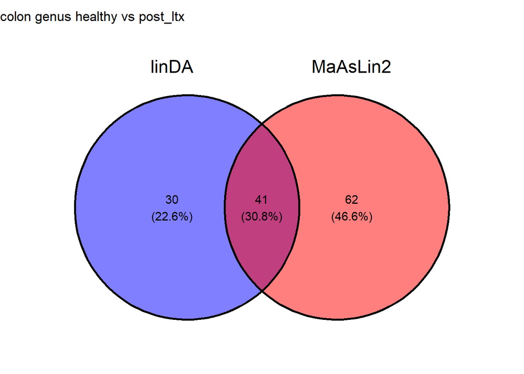

```r
intersection_results <- group_intersection(group, list_intersections, list_venns,
                                           linda.output, fit_data,
                                           raw_linda_results_genus,
                                           segment = segment,
                                           level=level)

list_intersections <- intersection_results[[1]]
list_venns <- intersection_results[[2]]
venn <- intersection_results[[3]]

# show the results
venn
```

###### 3.4.1.1.3.4 Interaction effect

```r
list_interaction_significant <- country_interaction(group,
                                                    linda.output,
                                                    list_intersections,
                                          filt_colon_uni_data,
                                          filt_colon_uni_metadata,
                                          segment=segment,
                                          level=level)

# see the result
## significant interaction effect
list_interaction_significant[[1]]
```

```r
## results for czech cohort
list_interaction_significant[[2]]
```

```
[1] NA
```

```r
## results for norwegian cohort
list_interaction_significant[[3]]
```

```
[1] NA
```

Removing problematic taxa

```r
list_intersections <- removing_interaction_problems(group,
                                                    list_interaction_significant,
                                                    list_intersections,
                                                    segment=segment,
                                                    level=level)
```

###### 3.4.1.1.3.5 Basic statistics

```r
uni_df <-  merge(basic_univariate_statistics(linda_data,group),
                 raw_linda_results_genus[[segment]][[group1]],
                 by="SeqID",all=TRUE)
```

```
[1] "healthy"
[1] "post_ltx"
[1] "healthy"
[1] "post_ltx"
```

```r
uni_df[["final_sig"]] <- uni_df$SeqID %in% list_intersections[[paste(segment,level,comparison_name)]][["SeqID"]]
uni_statistics[[segment]][[paste(level,comparison_name)]] <- uni_df

# for comparison
new_name <- comparison_name
addWorksheet(wb, sheetName = new_name)
writeData(wb, sheet = new_name, uni_df, rowNames=FALSE)
```

##### 3.4.1.1.4 Visualization

Heatmap visualizing the linDA’s logFoldChange for taxa with p < 0.1.

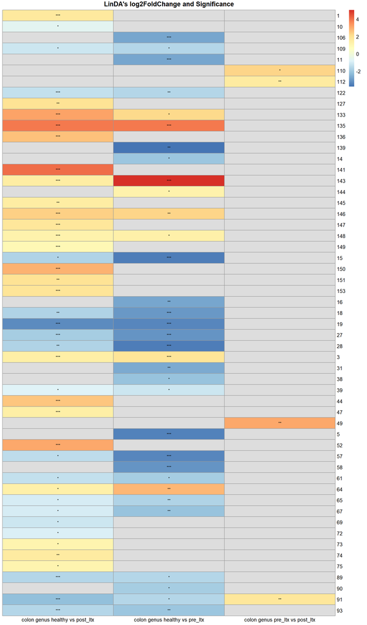

```r
list_heatmap <- list_intersections[grep(paste(segment,level),
                                  names(list_intersections),value=TRUE)]

p_heatmap_linda <- heatmap_linda(list_heatmap,colon_taxa_tab)
p_heatmap_linda
```

Dot heatmap

```r
dotheatmap_linda <- dot_heatmap_linda(list_heatmap,
                                      uni_statistics$colon[grepl(level,names(uni_statistics$colon))],
                                      colon_taxa_tab) + xlab("") + ylab("")
```

```
min_clr -2.221209
max_clr 6.886638
min_log -3.771476
max_log 5.049706
```

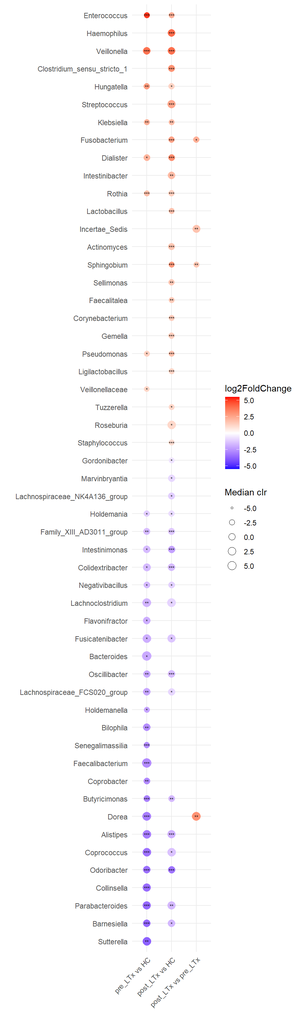

```r
dotheatmap_linda
```

**Horizontal bar plot**

```r
p_prevalence <- horizontal_barplot(wb,taxa=levels(dotheatmap_linda$data$SeqID))
```

```r
p_prevalence_final <- ggarrange(p_prevalence,
                                ggplot() + theme_minimal(),
                                nrow = 2,heights = c(1,0.09))
p <- ggarrange(dotheatmap_linda + theme(legend.position = "none"),p_prevalence_final,ncol=2,widths = c(1,0.3))

dot_heatmap_colon <- p
```

##### 3.4.1.1.5 PSC effect

**pre_LTx vs HC and Post_LTx vs HC intersection**

```r
A <- list_intersections[[paste(segment,level,"healthy vs pre_ltx")]]$SeqID
B <- list_intersections[[paste(segment,level,"healthy vs post_ltx")]]$SeqID
C <- intersect(A,B)

psc_effect[[paste(segment,level)]] <- list_intersections[[paste(segment,level, "healthy vs pre_ltx")]][list_intersections[[paste(segment,level, "healthy vs pre_ltx")]]$SeqID %in% C,]

# see the results
psc_effect[[paste(segment,level)]]
```

```
                           SeqID
3                         Rothia
15                   Barnesiella
18                 Butyricimonas
19                   Odoribacter
27                     Alistipes
28               Parabacteroides
39                    Holdemania
57                   Coprococcus
61              Fusicatenibacter
64                    Hungatella
65             Lachnoclostridium
67  Lachnospiraceae_FCS020_group
89              Colidextribacter
91                Intestinimonas
```

[output cut: 54 more lines]

#### 3.4.1.2 Saving results

```r
# ALL DATA
saveWorkbook(wb,file.path(path,paste0("uni_analysis_wb_",segment,".xlsx")),
             overwrite = TRUE)

# PSC effect
write.xlsx(psc_effect[[paste(segment,level)]],file.path(path,paste0("psc_effect_",segment,".xlsx")))

# SIGNIFICANT taxa

write.xlsx(list_intersections[grepl(segment,names(list_intersections))] %>%
            `names<-`(gsub(segment, "", names(
              list_intersections[grepl(segment,names(list_intersections))]))),
           file.path(path,paste0("significant_taxa_",segment,".xlsx")))
```